# Does Covid-19 Affect Los Angeles Crime?

## What you need

The following tools are needed to follow this tutorial. The ones commonly used in most data analysis include: [pandas](https://pandas.pydata.org/docs/user_guide/index.html#user-guide), [numpy](https://numpy.org/doc/stable/user/index.html#user), [matplotlib](https://matplotlib.org/stable/users/index.html), and [scikit-learn](https://scikit-learn.org/stable/user_guide.html)

```python
# often essential libaries
import pandas as pd
import numpy as np
import matplotlib.pyplot as plt

# useful libraries/modules that may or may not be necessary for a project
import datetime
from matplotlib import dates as mdates
from matplotlib.ticker import PercentFormatter

# prediction algorithms used for machine learning
from sklearn import linear_model
from sklearn.preprocessing import PolynomialFeatures
```

# Introduction

For this tutorial we will be analyzing LAPD crime date from 2010 to the present(2022) to see whether Covid-19 has any affect to the number of crimes or types of crimes in Los Angeles. Los Angeles is a very popular location for vacations so hopefully this tutorial could shed some light on whether there could be increased dangers with Covid-19 around. Now onto the first step of the tutorial.

# Getting the Data

Data collection is the first part of the data science pipeline. There are various means of getting data whether it be creating your own dataset, finding a file online, or scraping the data from a website's HTML. In our case, we're lucky and don't need to scrape the data. We'll instead be grabbing a file of crime data from Los Angeles' public data website https://data.lacity.org/.

If you want to know what web scraping is and why it is a painstaking process, here is a good resource: [link](https://realpython.com/beautiful-soup-web-scraper-python/)

For us to view the data we will store it in a dataframe. A dataframe is like a table where each row is an entry in the table and the columns are the attributes/categories of an entry. To store the data in the dataframe we will first download a csv file off the website and use [pandas.read_csv()](https://www.w3schools.com/python/pandas/pandas_csv.asp) to convert this csv file into a dataframe. In this scenerio the LAPD have 2 different datasets for 2010-2019 and 2020-Present so we'll have to create 2 dataframes.

Los Angeles crime data by the LAPD: [2010-2019](https://data.lacity.org/Public-Safety/Crime-Data-from-2010-to-2019/63jg-8b9z) and [2020-Present](https://data.lacity.org/Public-Safety/Crime-Data-from-2020-to-Present/2nrs-mtv8)

```python
ten_df = pd.read_csv('LA_Crime_Data_from_2010_to_2019.csv')
twen_df = pd.read_csv('LA_Crime_Data_from_2020_to_Present.csv')
```

Next, we'll want covid-19 data from Los Angeles, but in this case there isn't a simple csv that only includes Los Angeles so we'll have to grab a csv that includes every county in the US. We'll have to modify this data to get only Los Angeles' data. We will be using a URL this time so there's no need to download a file before reading the data.

Covid-19 data from the New York Times: [link](https://github.com/nytimes/covid-19-data)

Be warned that due to Githubs 100MB file limit, the us-counties.csv I use will likely be no longer up to date for you. Therefore, you will likely have to combine the us-counties-2020.csv up to the us-counties-202#.csv dataframes in order to get the full picture of the data. This will be similar to what we do in the next step with the LAPD crime datasets.

```python
covid_df = pd.read_csv('https://raw.githubusercontent.com/nytimes/covid-19-data/master/us-counties.csv')
```

Right now we have 2 crime dataframes, but it would be much easier to work with just one. So we will be combining the 2 dataframes with the [pandas concat](https://sparkbyexamples.com/pandas/pandas-concat-dataframes-explained/) function.

```python
crimes_df = pd.concat([ten_df, twen_df], ignore_index = True)

# .head()  shows only the first 5 rows in the dataframe
crimes_df.head()
```

|  | DR_NO | Date Rptd | DATE OCC | TIME OCC | AREA | AREA NAME | Rpt Dist No | Part 1-2 | Crm Cd | Crm Cd Desc | ... | Status Desc | Crm Cd 1 | Crm Cd 2 | Crm Cd 3 | Crm Cd 4 | LOCATION | Cross Street | LAT | LON | AREA |
| --- | --- | --- | --- | --- | --- | --- | --- | --- | --- | --- | --- | --- | --- | --- | --- | --- | --- | --- | --- | --- | --- |
| 0 | 1307355 | 02/20/2010 12:00:00 AM | 02/20/2010 12:00:00 AM | 1350 | 13.0 | Newton | 1385 | 2 | 900 | VIOLATION OF COURT ORDER | ... | Adult Arrest | 900.0 | NaN | NaN | NaN | 300 E GAGE AV | NaN | 33.9825 | -118.2695 | NaN |
| 1 | 11401303 | 09/13/2010 12:00:00 AM | 09/12/2010 12:00:00 AM | 45 | 14.0 | Pacific | 1485 | 2 | 740 | VANDALISM - FELONY ($400 & OVER, ALL CHURCH VA... | ... | Invest Cont | 740.0 | NaN | NaN | NaN | SEPULVEDA BL | MANCHESTER AV | 33.9599 | -118.3962 | NaN |
| 2 | 70309629 | 08/09/2010 12:00:00 AM | 08/09/2010 12:00:00 AM | 1515 | 13.0 | Newton | 1324 | 2 | 946 | OTHER MISCELLANEOUS CRIME | ... | Invest Cont | 946.0 | NaN | NaN | NaN | 1300 E 21ST ST | NaN | 34.0224 | -118.2524 | NaN |
| 3 | 90631215 | 01/05/2010 12:00:00 AM | 01/05/2010 12:00:00 AM | 150 | 6.0 | Hollywood | 646 | 2 | 900 | VIOLATION OF COURT ORDER | ... | Invest Cont | 900.0 | 998.0 | NaN | NaN | CAHUENGA BL | HOLLYWOOD BL | 34.1016 | -118.3295 | NaN |
| 4 | 100100501 | 01/03/2010 12:00:00 AM | 01/02/2010 12:00:00 AM | 2100 | 1.0 | Central | 176 | 1 | 122 | RAPE, ATTEMPTED | ... | Invest Cont | 122.0 | NaN | NaN | NaN | 8TH ST | SAN PEDRO ST | 34.0387 | -118.2488 | NaN |

5 rows × 29 columns

```python
covid_df.head()
```

|  | date | county | state | fips | cases | deaths |
| --- | --- | --- | --- | --- | --- | --- |
| 0 | 2020-01-21 | Snohomish | Washington | 53061.0 | 1 | 0.0 |
| 1 | 2020-01-22 | Snohomish | Washington | 53061.0 | 1 | 0.0 |
| 2 | 2020-01-23 | Snohomish | Washington | 53061.0 | 1 | 0.0 |
| 3 | 2020-01-24 | Cook | Illinois | 17031.0 | 1 | 0.0 |
| 4 | 2020-01-24 | Snohomish | Washington | 53061.0 | 1 | 0.0 |

# Processing the Data

The next step of the data science pipeline is processing the data, otherwise known as data wrangling. Most of the time the dataframe we get from reading a file will have issues. So in this step we will be fixing up the dataframe so that it will be easier to understand and easier to analyze. Something important to know is often times this is the step that requires the [most time](https://medium.com/analytics-vidhya/a-data-cleaning-journey-2b0146407e44) for a data scientist. Don't worry if you feel like you've been at this step for a long time.

More info on data wrangling at: [link](https://online.hbs.edu/blog/post/data-wrangling)

#### We'll start with cleaning our LAPD crime dataframe.

One of the first things to do is to see if our dataframe contains any missing or duplicated data in its entries. Of course, if you won't be using an attribute in your dataframe that has missing values then there's not much of a reason. With our crime dataframe, we want to first check if there are duplicates so we need to use something that can be unique to each crime. It just so happens that each crime has a unique 'DR_NO' so we can count how many of these unique 'DR_NO' values are in the dataframe and compare it to the number of entries in the dataframe.

Info about how to access columns or rows in the dataframe here: [link](https://pandas.pydata.org/pandas-docs/stable/getting_started/intro_tutorials/03_subset_data.html)

```python
num_ids = crimes_df['DR_NO'].unique().size
print(f'duplicate entries: {crimes_df.index.size - num_ids}')

# removes all the entries that have duplicate 'DR_NO' besides the first occurrence
crimes_df.drop_duplicates(['DR_NO'], inplace = True)
print(f'duplicate entries after removal: {crimes_df.index.size - num_ids}')
```

```
duplicate entries: 227308
duplicate entries after removal: 0
```

After checking for duplicates, now we want to check if there are any missing values in our columns of interest. It's very important to check for missing values because they can completely change how we view the data. Sometimes the values missing could have contributed a lot to what the trend of the data actually is. So make sure you know whether your data has missing values so you can be sure whether your analysis is completely accurate or possibly unreliable.

```python
# we will look at every entry in the column to see if any values are null with .isnull() and if there is any missing value the function returns true
series_dateocc = crimes_df['DATE OCC'].isnull().values.any()
series_timeocc = crimes_df['TIME OCC'].isnull().values.any()
series_crm = crimes_df['Crm Cd Desc'].isnull().values.any()

print(f'Are there missing values in column \'DATE OCC\': {series_dateocc}')
print(f'Are there missing values in column \'TIME OCC\': {series_timeocc}')
print(f'Are there missing values in column \'Crm Cd Desc\': {series_crm}')
```

```
Are there missing values in column 'DATE OCC': False
Are there missing values in column 'TIME OCC': False
Are there missing values in column 'Crm Cd Desc': False
```

In this case we were lucky and there happens to be no missing values in our columns of interest. So we can proceed to the next step.

After reading in the csv file, the dataframe we get sets dates as Strings rather than actual dates. In order to analyze and graph by date we'll need to convert these strings into [datetime objects](https://www.w3schools.com/python/python_datetime.asp). The added parameter errors='coerce' in pd.to_datetime() changes any value that can't be converted to a date variable to be NaT (not a time). We then use the method dropna() based on the 'DATE OCC' attribute to remove any entries that contain these NaT from our dataframe.

```python
# converts the whole column of strings into datetime then removes any rows where dates couldn't be converted to datatime
crimes_df['DATE OCC'] = pd.to_datetime(crimes_df['DATE OCC'], errors = 'coerce')
crimes_df.dropna(subset = ['DATE OCC'], inplace = True)
```

After fixing the date, now we need to convert the hour a crime occured from integer to datetime. It's important to always check the datatype of a value in your dataframe as this can make it much easier to discern how you go about cleaning the data.

```python
crimes_df['TIME OCC'].dtype
```

```
dtype('int64')
```

In order to be converted to a datetime object we'll have to first convert the time from an integer to a string then we can convert the string into datetime. However, we must first format the string so that it can be accepted by the pd.datetime() function. We do this by making every converted string into the same length by filling them with leading zeroes until they have a length of 4. Then add a semicolon in the middle of the string to separate the numbers that correspond to hours from the minutes.

```python
crimes_df['TIME OCC'] = crimes_df['TIME OCC'].astype(str)

# adds leading zeroes to the string until it has a length of 4
crimes_df['TIME OCC'] = crimes_df['TIME OCC'].map(lambda string: string.zfill(4))
crimes_df['TIME OCC'] = crimes_df['TIME OCC'].map(lambda string: string[0:2] + ':' + string[2:])

crimes_df['TIME OCC'] = pd.to_datetime(crimes_df['TIME OCC'], format='%H:%M').dt.time
crimes_df.head()
```

|  | DR_NO | Date Rptd | DATE OCC | TIME OCC | AREA | AREA NAME | Rpt Dist No | Part 1-2 | Crm Cd | Crm Cd Desc | ... | Status Desc | Crm Cd 1 | Crm Cd 2 | Crm Cd 3 | Crm Cd 4 | LOCATION | Cross Street | LAT | LON | AREA |
| --- | --- | --- | --- | --- | --- | --- | --- | --- | --- | --- | --- | --- | --- | --- | --- | --- | --- | --- | --- | --- | --- |
| 0 | 1307355 | 02/20/2010 12:00:00 AM | 2010-02-20 | 13:50:00 | 13.0 | Newton | 1385 | 2 | 900 | VIOLATION OF COURT ORDER | ... | Adult Arrest | 900.0 | NaN | NaN | NaN | 300 E GAGE AV | NaN | 33.9825 | -118.2695 | NaN |
| 1 | 11401303 | 09/13/2010 12:00:00 AM | 2010-09-12 | 00:45:00 | 14.0 | Pacific | 1485 | 2 | 740 | VANDALISM - FELONY ($400 & OVER, ALL CHURCH VA... | ... | Invest Cont | 740.0 | NaN | NaN | NaN | SEPULVEDA BL | MANCHESTER AV | 33.9599 | -118.3962 | NaN |
| 2 | 70309629 | 08/09/2010 12:00:00 AM | 2010-08-09 | 15:15:00 | 13.0 | Newton | 1324 | 2 | 946 | OTHER MISCELLANEOUS CRIME | ... | Invest Cont | 946.0 | NaN | NaN | NaN | 1300 E 21ST ST | NaN | 34.0224 | -118.2524 | NaN |
| 3 | 90631215 | 01/05/2010 12:00:00 AM | 2010-01-05 | 01:50:00 | 6.0 | Hollywood | 646 | 2 | 900 | VIOLATION OF COURT ORDER | ... | Invest Cont | 900.0 | 998.0 | NaN | NaN | CAHUENGA BL | HOLLYWOOD BL | 34.1016 | -118.3295 | NaN |
| 4 | 100100501 | 01/03/2010 12:00:00 AM | 2010-01-02 | 21:00:00 | 1.0 | Central | 176 | 1 | 122 | RAPE, ATTEMPTED | ... | Invest Cont | 122.0 | NaN | NaN | NaN | 8TH ST | SAN PEDRO ST | 34.0387 | -118.2488 | NaN |

5 rows × 29 columns

#### Next is cleaning the covid-19 dataframe

As mentioned earlier the dataframe we have actually contains every country in the US. But since we are focused on Los Angeles, we'll only grab the entries that have Los Angeles as the county.

```python
covid_df = covid_df[covid_df['county'] == 'Los Angeles']
covid_df = covid_df.reset_index()
covid_df.drop('index', axis = 1, inplace = True)
```

We'll check if there's any missing data or duplicates much like with our crimes dataframe.

```python
# use the date of each entry to see if there are any duplicates
num_dates = covid_df['date'].unique().size
print(f'duplicate entries: {covid_df.index.size - num_dates}')

series_cases = covid_df['cases'].isnull().values.any()
print(f'Are there missing values in column \'cases\': {series_cases}')
```

```
duplicate entries: 0
Are there missing values in column 'cases': False
```

Looks like there's no missing or duplicate values in our covid-19 dataframe. However, the covid cases data from the New York Times only records the cumulative number of covid cases. So if we want to view the number of cases that occur each day we'll have to subtract the cumulative number of covid cases from the day before with the cumulative cases today.

```python
# renames the columns 'cases' into 'cumulative cases' and 'deaths' into 'cumulative deaths'
covid_df.rename(columns = {'cases': 'cumulative cases', 'deaths': 'cumulative deaths'}, inplace = True)

# subtract the current day's cumulative cases with the one the day before to get the number of cases on this day
for i in range(1, len(covid_df)):
    covid_df.loc[i, 'cases'] = covid_df['cumulative cases'][i] - covid_df['cumulative cases'][i - 1]

# the loop doesn't take into account the very first entry, but we know that the cumulative covid cases should be the same as the
# first recorded day of covid cases
covid_df.loc[0, 'cases'] = covid_df['cumulative cases'][0]
```

```python
covid_df[covid_df['cases'] >= 5].head()
```

|  | date | county | state | fips | cumulative cases | cumulative deaths | cases |
| --- | --- | --- | --- | --- | --- | --- | --- |
| 38 | 2020-03-04 | Los Angeles | California | 6037.0 | 7 | 0.0 | 6.0 |
| 43 | 2020-03-09 | Los Angeles | California | 6037.0 | 19 | 0.0 | 5.0 |
| 45 | 2020-03-11 | Los Angeles | California | 6037.0 | 28 | 1.0 | 8.0 |
| 47 | 2020-03-13 | Los Angeles | California | 6037.0 | 40 | 1.0 | 8.0 |
| 48 | 2020-03-14 | Los Angeles | California | 6037.0 | 53 | 1.0 | 13.0 |

Even though the covid-19 dataframe's entries start in January of 2020, covid cases only start to increase in March. So, if we were to see how crime is affected during covid then it would make more sense to mark where exactly when covid was rampent. Thus, we will be marking every crime entry that occurs March 2020 or later with a 'Y' and everything else with a 'N'

```python
crimes_df['covid period'] = np.where((crimes_df['DATE OCC'] >= pd.Timestamp(2020, 3, 1)), 'Y', 'N')
```

# Exploratory Data Analysis

After finally cleaning up our dataframes, we can now jump into the next part of the data science pipeline, analyzing our data. Data analysis includes plotting our data to notice any trends or anomalies in the data or applying statistical analysis in order to help confirm if relationships exist within the data.

For more detailed info on what is data analysis: [link](https://towardsdatascience.com/exploratory-data-analysis-8fc1cb20fd15)

In this tutorial we will mainly be plotting crime data overtime to see if Covid-19 had any effect on the number of crimes, types of crimes, or times of crimes. There are many other areas we can look at like whether the season affects covid-19 and crime or if there is a change in locations of crimes with covid-19. But for now, we will only be doing much more general covid-19 and crime analysis so you can potentially try one of those ideas yourselves.

```
An important thing to note: Although I'm separating the data science pipeline into parts, the life cycle of data science isn't sequential. You will often be doing data processing in all the other parts and vise versa.
```

Below we are going to create a scatterplot of the number of reported crimes per year (2010-2021). It's possible that covid-19 had some affect to the number of crimes that occurred in 2020-2022 compared to 2010-2019.

For more info of the matplotlib scatter function: [link](https://www.geeksforgeeks.org/matplotlib-pyplot-scatter-in-python/)

We won't be including the number of crimes that occurred in 2022 because the year isn't finished yet at the time of this tutorial. If we were to include an unfinished year, then it's possible that it could affect our perception of the graph.

It's important to always be mindful about what you should and shouldn't include when analyzing the data. Sometimes you might discover an interesting relationship between certain attributes that you may not have seen had you simply never plotted the 2 together.

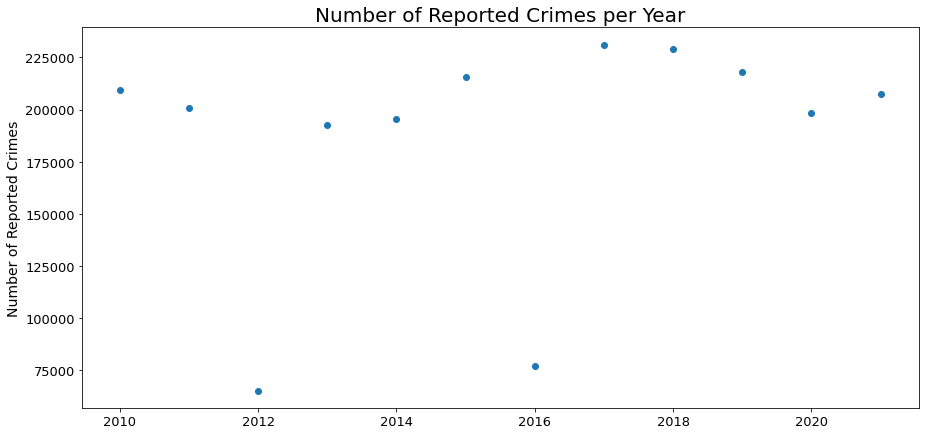

```python
# grab all unique years from the dataset and put them in a list
years = crimes_df['DATE OCC'].dt.year.unique()
years.sort()

# This excludes the last element of the list which means excluding 2022
cut_years = years[:-1]

# store the number of crimes occuring per year
crimes_per_year = []
for year in cut_years:
    crimes_per_year.append(crimes_df[crimes_df['DATE OCC'].dt.year == year].index.size)

# plot the data, the last line is what plots the data the rest of the lines simply format the graph to make it easier to read
plt.figure(figsize=(15,7))
plt.title('Number of Reported Crimes per Year', fontsize = 20)
plt.ylabel('Number of Reported Crimes', fontsize = 14)
plt.xticks(fontsize = 13)
plt.yticks(fontsize = 13)
plt.scatter(cut_years, crimes_per_year)
```

[output not shown]

Also notice how despite 2020 also having a presidential election occurring, there isn't a sharp decrease in reported crimes. These questions are what makes data science so interesting as there could be thousands of answers for why the data does what it does, and you will have to discover the most likely answer through analysis. You will likely need to use other datasets to see if there are any correlations you could find between datasets.

In this case, there isn't any attribute in our dataframe that could help with explaining these trends so we will be moving on to analyze another part of our data.

Next we will be looking to see whether Covid-19 affected what times crimes occur at. For this we will create a function that creates an array with every hour for each entry in the given dataframe. Then we will plot a histogram which counts the number of occurrences of each hour in the array and plots the occurrences.

For more info on matplotlib histograms: [link](https://matplotlib.org/3.5.0/api/_as_gen/matplotlib.pyplot.hist.html)

```python
# takes in a dataframe, returns an array that includes the hours of all entries in the dataframe
def get_crime_hours(df):
    hours = []

    for i in range(len(df)):
        hours.append(df['TIME OCC'][i].hour)

    return hours
```

```python
# group the crime datarframe by whether the crime was committed during covid or not
group_covid_period = crimes_df.groupby('covid period')

# we create a copies of grouped dataframes so that any modifications that occur if these copies won't affect the original
not_covid_df = group_covid_period.get_group('N').copy()
during_covid_df = group_covid_period.get_group('Y').copy()

# reset the index of the copied dataframes so that we can loop through the dataframes using indicies
not_covid_df.reset_index(inplace = True)
not_covid_df.drop('index', axis = 1, inplace = True)
during_covid_df.reset_index(inplace = True)
during_covid_df.drop('index', axis = 1, inplace = True)

not_covid_crimehours = get_crime_hours(not_covid_df)
during_covid_crimehours = get_crime_hours(during_covid_df)
```

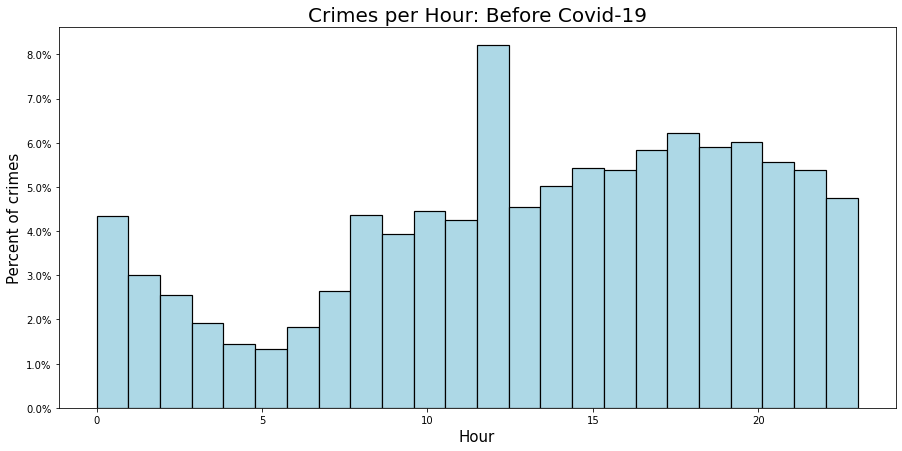

```python
plt.figure(figsize=(15, 7))
plt.title('Crimes per Hour: Before Covid-19', fontsize = 20)
plt.xlabel('Hour', fontsize = 15)
plt.ylabel('Percent of crimes', fontsize = 15)

# bins=24 as there are 24 hours in a day, density=True plots the ratio rather than the actual values
plt.hist(not_covid_crimehours, bins=24, density=True, color="lightblue", edgecolor='black', linewidth=1.2)

# converts the y axis from decimal to percentage
plt.gca().yaxis.set_major_formatter(PercentFormatter(1))
```

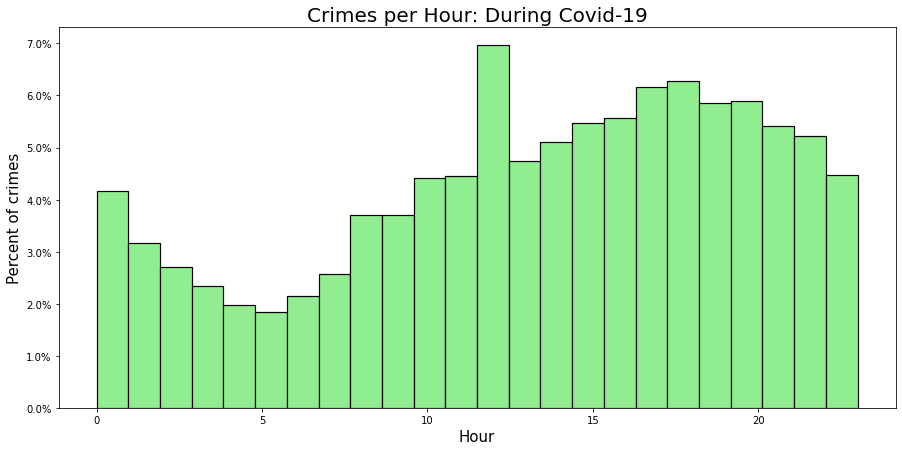

```python
plt.figure(figsize=(15, 7))
plt.title('Crimes per Hour: During Covid-19', fontsize = 20)
plt.xlabel('Hour', fontsize = 15)
plt.ylabel('Percent of crimes', fontsize = 15)

# bins=24 as there are 24 hours in a day, density=True plots the ratio rather than the actual values
plt.hist(during_covid_crimehours, bins=24, density=True, color="lightgreen", edgecolor='black', linewidth=1.2)

# converts the y axis from decimal to percentage
plt.gca().yaxis.set_major_formatter(PercentFormatter(1))
```

When observing the histograms the most notable difference is that the percentage of crimes at 12 had decreased from a little above 8% to below 7%. We can also see that 12 o'clock before and during Covid-19 has the most crimes occur in the day. One explanation for this could be that because it was around lunchtime there would be more people in the streets so more likely for people to commit a crime in the crowd. Or it's possible that whenever a crime occurs a little before or after noon that most people default to reporting the crime as being at noon. Besides these observations, there doesn't seem to be a noticeable difference in the times crimes occur before and during Covid-19.

So after a lack of results, how about we look at a more specific time frame and only look at crimes that occur during Covid-19. There could be a correlation between number of crimes that occur in a day and number of covid positives.

```python
covid_dates = covid_df['date']
crimes_per_date = []

# record the number of crimes that occur each day
for date in covid_dates:
    crimes_per_date.append(crimes_df[crimes_df['DATE OCC'] == date].index.size)
```

To help make the data easier to understand we will be plotting both the number of covid cases per day and the number of crimes per day stacked on top of each other. We will use the matplotlib subplots function in order to do this.

For info on how subplots work: [link](https://matplotlib.org/3.5.0/gallery/subplots_axes_and_figures/subplots_demo.html)

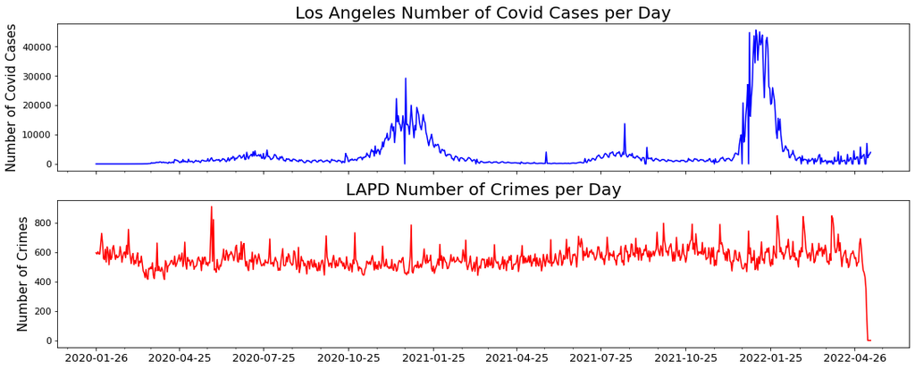

```python
fig, axs = plt.subplots(2, 1, figsize=(15, 6), constrained_layout=True, sharex= True)
axs[0].plot(covid_df['date'], covid_df['cases'], color = 'b')
axs[1].plot(covid_df['date'], crimes_per_date, color = 'r')

# sets labeled Major ticks every quarter year and unlabeled minor ticks every month for the time period
for i in range(len(axs)):
    axs[i].xaxis.set_major_locator(mdates.MonthLocator(bymonth=(1, 4, 7, 10)))
    axs[i].xaxis.set_minor_locator(mdates.MonthLocator())
    axs[i].tick_params(axis='x', labelsize=13)
    axs[i].tick_params(axis='y', labelsize=11)

# top plot will be covid cases per day
axs[0].set_ylabel(r'Number of Covid Cases', fontsize = 15)
axs[0].set_title('Los Angeles Number of Covid Cases per Day', fontsize = 20)

# bottom plot is number of crimes per day
axs[1].set_ylabel(r'Number of Crimes', fontsize = 15)
axs[1].set_title('LAPD Number of Crimes per Day', fontsize = 20)

plt.show()
```

Note: the number of crimes graph drops to almost zero around May 2022 because that dataset isn't updated as often as the covid-19 data

Observing the plots we can see that there are large spikes in covid cases around December 2020 and December 2021. Interestingly we can also observe that smaller spikes in number of crimes had occurred the day after the large spike in December 2020. But this trend doesn't also occur during December 2021 which makes it hard to tell whether Covid-19 was the cause of the spike in crimes. There is also a very large spike in crimes around May 25 2020, but it's likely that this wasn't caused by Covid-19 as that was around the time the [George Floyd](https://en.wikipedia.org/wiki/George_Floyd) controversy occurred. In general, there doesn't seem to be much of a correlation between number of covid cases and crimes per day. There are increases in crime where there is a low amount of covid cases such as between 2021-7-25 and 2021-11-25. There does seem to be a slight increase in the number of crimes overtime, but it's too difficult to tell.

So after another failure to observe if covid had any effect on number of crimes, we should move on to a different topic. We can observe if Covid-19 has any effect on what types of crimes would occur. For this we be recording the occurrences of each type of crime and graphing the top 10 most common crimes in Los Angeles. We will graph the percentage of each crime for times periods 2010-2019, 2020, 2021, and 2022 in order to observe if covid-19 had affected what types of crimes would occur more often or less.

```python
types_of_crimes = crimes_df['Crm Cd Desc'].unique()

# create array of tuples that have the type of crimes and the occurence of this type of crime
num_type_crimes = []
for crime in types_of_crimes:
    num_type_crimes.append((crime, crimes_df[crimes_df['Crm Cd Desc'] == crime].index.size))

# sort the array by the most occurring types of crimes
num_type_crimes = sorted(num_type_crimes, key = lambda x: x[1], reverse = True)
num_type_crimes[0:10]
```

```
[('BATTERY - SIMPLE ASSAULT', 206075),
 ('VEHICLE - STOLEN', 190161),
 ('BURGLARY FROM VEHICLE', 171455),
 ('THEFT PLAIN - PETTY ($950 & UNDER)', 156451),
 ('BURGLARY', 156307),
 ('THEFT OF IDENTITY', 131465),
 ('VANDALISM - FELONY ($400 & OVER, ALL CHURCH VANDALISMS)', 126093),
 ('INTIMATE PARTNER - SIMPLE ASSAULT', 124736),
 ('ASSAULT WITH DEADLY WEAPON, AGGRAVATED ASSAULT', 109492),
 ('THEFT FROM MOTOR VEHICLE - PETTY ($950 & UNDER)', 96583)]
```

```python
# create an array of only the names of the top 10 crimes
top_10_crimes = [x[0] for x in num_type_crimes[0:10]]
```

```python
# counts the percentage that the given list of crimes each occur for a time period
def get_perc_crimes(df, crime_lst):
    crime_num = []

    for crime in crime_lst:
        crime_num.append((crime, (df[df['Crm Cd Desc'] == crime].index.size) / df.index.size))

    return crime_num
```

We will be grouping the crime dataframe by time periods and calculating the percentage that each of the 10 most common crimes occurs in each time period. Percentage is calculated by the number of this type of crime over the total number of crimes in the time period.

```python
# add extra columns for the year and month that each crime occurs
crimes_df['year'] = crimes_df['DATE OCC'].dt.year
crimes_df['month'] = crimes_df['DATE OCC'].dt.month

# group the data frame by the time period
pre2020crime_df = crimes_df[crimes_df['year'] < 2020]
year20crime_df = crimes_df[crimes_df['year'] == 2020]
year21crime_df = crimes_df[crimes_df['year'] == 2021]
year22crime_df = crimes_df[crimes_df['year'] == 2022]

# get the percentage that each of the top 10 crimes occur in each time period
pre2020crime_lst = get_perc_crimes(pre2020crime_df, top_10_crimes)
year20crime_lst = get_perc_crimes(year20crime_df, top_10_crimes)
year21crime_lst = get_perc_crimes(year21crime_df, top_10_crimes)
year22crime_lst = get_perc_crimes(year22crime_df, top_10_crimes)
```

We will now create a new dataframe that only contains the relevant information of the percentage that each of the 10 most common crimes per time period. This is done so that the [dataframe.plot()](https://realpython.com/pandas-plot-python/) function can create a bar graph for the data.

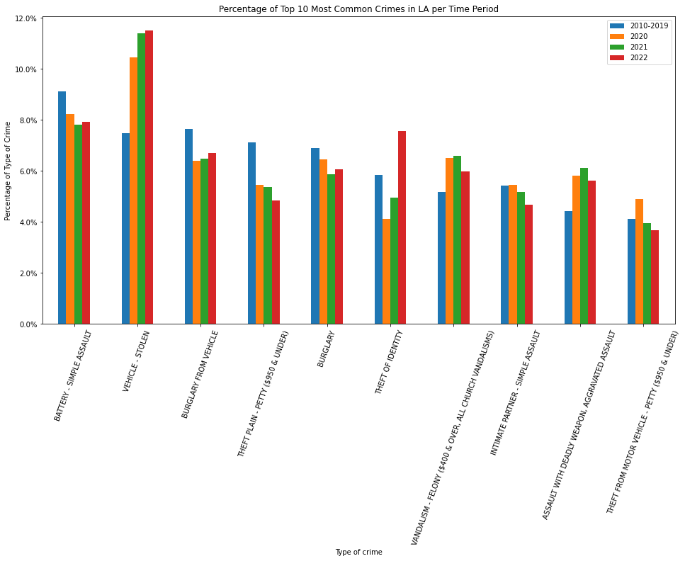

```python
crime_percentage_df = pd.DataFrame(columns = ['Type of crime', '2010-2019', '2020', '2021', '2022'])
crime_percentage_df['Type of crime'] = top_10_crimes
crime_percentage_df['2010-2019'] = [x[1] for x in pre2020crime_lst]
crime_percentage_df['2020'] = [x[1] for x in year20crime_lst]
crime_percentage_df['2021'] = [x[1] for x in year21crime_lst]
crime_percentage_df['2022'] = [x[1] for x in year22crime_lst]

crime_percentage_df.plot.bar(x='Type of crime', figsize=(16, 8), title='Percentage of Top 10 Most Common Crimes in LA per Time Period', rot=70, fontsize=10, ylabel='Percentage of Type of Crime')
plt.gca().yaxis.set_major_formatter(PercentFormatter(1))
```

# Machine Learning

For this phase of the data science pipeline we will be trying various algorithms like [Linear Regressions](https://www.geeksforgeeks.org/python-linear-regression-using-sklearn/) or [Polynomial Regressions](https://data36.com/polynomial-regression-python-scikit-learn/) to hopefully get a predictive model of a trend. A good model will allow us to predict values outside of our current data. In this case we will try to model what percentage of stolen vehicle crimes can occur during a year.

We've noticed that stolen vehicle crimes are incredible common in Los Angeles and often those on vacation will likely rent a car. So creating a model to see the percentage of stolen vehicle crimes in the future may help those wanting to vacation to Los Angeles think about whether it's a good idea.

We'll first calculate the percentage of crimes each year that are stolen vehicle crimes and store them in an array.

```python
# create a new dataframe that only has stolen vehicle crimes
vehicle_crime = crimes_df[crimes_df['Crm Cd Desc'] == 'VEHICLE - STOLEN'].copy()
vehicle_crime.reset_index(inplace = True)
vehicle_crime.drop('index', axis = 1,  inplace = True)

# create an array of the percentage of stolen vehicle crimes per year
vehicle_crime_percent = [vehicle_crime[vehicle_crime['DATE OCC'].dt.year == year].index.size / crimes_df[crimes_df['DATE OCC'].dt.year == year].index.size for year in years]
vehicle_crime_percent
```

```
[0.07975163948530677,
 0.07553720325559618,
 0.07167104434511466,
 0.07237139194120182,
 0.0700519035565442,
 0.07455652044830402,
 0.07336531442277609,
 0.08128192816945883,
 0.0744146646056573,
 0.07047361945163719,
 0.10460449356621354,
 0.11388655725684294,
 0.11505144897102058]
```

Now we will be creating a linear regression algorithm (like y=mx+b) to fit our percentage array with the years they occur. Fitting the data simply means that our model will try to be as accurate as possible to the data we give it so that it's predictions can be accurate.

```python
# linear_model only accepts 2 dimensional arrays so we have to create a 2d array for the years
years_ = [[year] for year in years]
lm = linear_model.LinearRegression()
lm.fit(years_, vehicle_crime_percent)
```

```
LinearRegression()
```

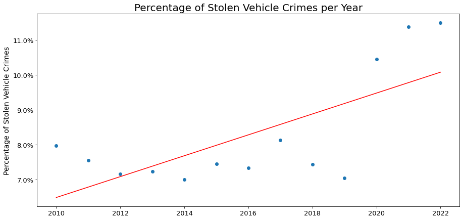

```python
plt.figure(figsize=(15,7))
plt.title('Percentage of Stolen Vehicle Crimes per Year', fontsize = 20)
plt.ylabel('Percentage of Stolen Vehicle Crimes', fontsize = 14)
plt.xticks(fontsize = 13)
plt.yticks(fontsize = 13)
plt.scatter(years, vehicle_crime_percent)
plt.gca().yaxis.set_major_formatter(PercentFormatter(1))

# plot the model's predictions
plt.plot(years_, lm.predict(years_), color = 'r')
```

Our model is the red line and as we can see it doesn't line up with our data at all. A linear regression is only a straight line and since our data isn't linear, the model of course won't be able to match it. We can even measure how well our line fits the data by using the R^2 value. A R^2 value of 1 means that our model fits the data perfectly while a value of 0 means that it doesn't fit the data at all.

For more info about what is R^2: [link](https://blog.minitab.com/en/adventures-in-statistics-2/regression-analysis-how-do-i-interpret-r-squared-and-assess-the-goodness-of-fit)

```python
lm.score(years_, vehicle_crime_percent)
```

```
0.4915418892937966
```

An R^2 of .49 is not good at all. So let's try using a polynomial regression instead. We'll use a polynomial of degree 3 as that fits the data better than a degree of 2 and fits about the same as a degree of 4. What degree you choose depends on how well the model fits the data and whether it's worth using a higher degree. With a higher degree, the computer will require more time and resources to compute the model.

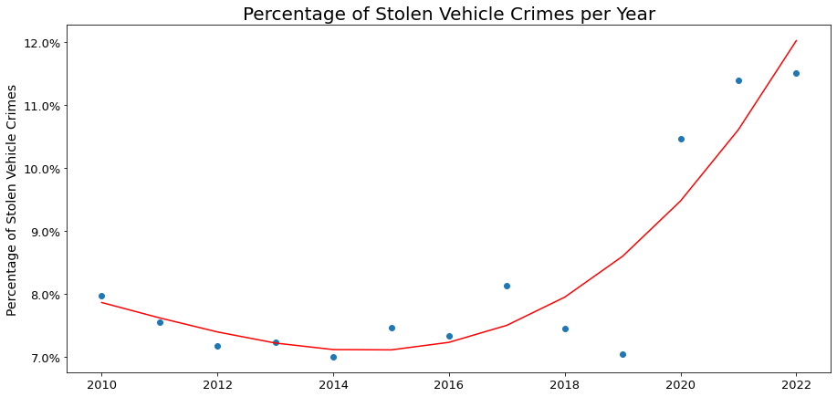

```python
plt.figure(figsize=(15,7))
plt.title('Percentage of Stolen Vehicle Crimes per Year', fontsize = 20)
plt.ylabel('Percentage of Stolen Vehicle Crimes', fontsize = 14)
plt.xticks(fontsize = 13)
plt.yticks(fontsize = 13)
plt.scatter(years, vehicle_crime_percent)
plt.gca().yaxis.set_major_formatter(PercentFormatter(1))

# polynomial regression of degree 3
poly = PolynomialFeatures(degree=3)

# fit the polynomial model
poly_years = poly.fit_transform(years_)
lm.fit(poly_years, vehicle_crime_percent)
poly_predict = lm.predict(poly_years)

plt.plot(years, poly_predict, color = 'r')
```

```python
print(lm.score(poly_years, vehicle_crime_percent))
```

```
0.8461119016666989
```

A R^2 of .846 is much better, but this also creates another problem. With a curve like this it seems as though the percentage of stolen vehicle crimes will increase a lot in the coming years which would be unrealistic. This would be a case of overfitting. Overfitting occurs when your model fits the data you have too well that it doesn't predict anything outside of your current data correctly. So despite the fact that our R^2 for a polynomial regression is good, this model likely isn't very helpful in predicting stolen vehicle crimes outside these set of years.

For more info on overfitting and how to prevent it: [link](https://medium.datadriveninvestor.com/the-problem-of-overfitting-in-regression-and-how-to-avoid-it-dac4d49d836f)

Based off the shape of our data points something like a bell-shaped curve or sigmoid curve would probably fit the data much better. However, the sklearn library doesn't include models of these types which makes it difficult for us to model and predict curves like those. Maybe you could be the one to discover a good method of modeling those types of curves.

# Insights Attained

This what most consider the last part of the data science pipeline and where we try to draw insights from our data analyzed.

After creating our graphs and models there doesn't seem to be a correlation between Covid-19 and the number of crimes that occur or times of crimes.

What we can say with some semblance of confidence is that the types of crimes that occur has changed after Covid-19 arrived. Most notably, stolen vehicles crimes have gone up around 3% compared to before and after covid-19. Our models, while flawed, also show an upward trend in percentage of stolen vehicle crimes. While there's no telling why there are more stolen vehicles, we now know that there is an increase. A suggestion would be to station more police officers at very populated LA parking areas to catch thieves in the act. If you ever go to Los Angeles, be careful about where you park and double check that your car in locked.

In general, our analysis doesn't give a good picture of whether Covid-19 affects Los Angeles crimes. But there are plenty of other means of analyzing our data such as using location of crimes or the perpetrator of crimes in conjunction with Covid-19. In the future, we can tackle how these attributes relate to one another and hopefully get more confident results. You might even beat me to the punch.